```python
import numpy as np
import matplotlib.pyplot as plt
from scipy.stats import norm
```

# 수리통계학

- 쉬운 개념 복습하기
- 확률밀도함수와 누적분포함수

# 확률밀도함수와 누적분포함수

`-` **확률밀도함수**

`-` 이산형

1. 모든 실수 x에 대하여 f(x)>0 이다
2. 확률 변수 X가 가질 수 있는 유한 또는 가산무한개의 값 $x_1,x_2, \cdot\cdot\cdot $에 대하여 $f(x_i)>0$이며 $\sum f(x_i) = 1$

`-` 연속형

1. 모든 실수 x에 대하여 f(x)>0 이다
2. $\int_{-\infty}^{\infty} f(x)\, dx$ = 1

`-` 쉬운 이해

1. 확률밀도함수란 확률이 일어날 분포에 대한 함수 $\rightarrow$ 어떤 변수에 대한 확률이 일어날 분포라는 공간에 대한 함수
2. 확률을 가지고 만든 공간이기 때문에 당연히 음수값, 0 밑으로 떨어질 수가 없다.
1. 모든 확률변수가 나타날 확률을 더하면 당연히 1로 나타남, 반대로 생각하면 1 이상이 될 수 없음
2. 이말은 확률일어날 분포에대한 공간 전체에 대한 확률을 의미하는 것

`-` 예시 : 정규분포의 확률밀도함수

$$ f(x;\mu,\sigma)= \frac{1}{\sqrt{2\pi}\sigma}e^{-(\frac{x-\mu}{2\sigma})^2} $$

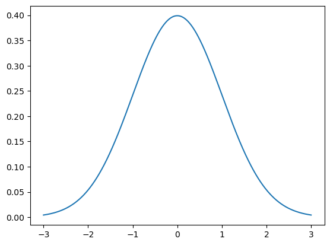

```python
m = 0 # 평균
s = 1 # 분산
x = np.arange(-3,3,0.001)

def nomal_distribution(x,m,s):
    return 1/np.sqrt(2*np.pi*s**2)*np.exp(- ((x-m)**2 / 2*s**2))

plt.plot(x,nomal_distribution(x,0,1))
```

- 윗 그래프는 표준정규분포의 확률밀도함수(확률이 나타나는 전체의 공간)이다
- $-\infty$에서 0까지의 확률은 해당 전체 공간(전체 넓이 = 1)의 절반이므로 0.5의 확률을 가진다
- 이를 계산하려면 적분이 필요

**확률밀도함수를 적분하면 누적분포함수이다**

- 연속형확률변수 X의 확률밀도함수가 $f(x)$이고 누적분포함수는 $F(x)$일 때, 밑을 만족함 $$ f(x) = \frac{d}{dx}F(x) $$

`-` 누적분포함수

- $F(x) = P(X\le x) $ 으로 정의됨
- X는 확률변수로 $P(X=x)$ 연속형일때 0이다.
- $F(x)$는 $f(x)$라는 확률이 나타날 공간에 대한 누적된 함수! 따라서 특정 확률변수 X가 일어나기전까지 모든 확률을 누적시키는 것이다

`-` 예시

- 표준정규분포를 따르는 확률변수 X에 대한 $F(X) = P(X \le x)$를 알아보자
- 우린 위에서 확률변수 0에 대한 확률을 구했다

$$ F(0) = P(0 \le x) \\ \int^{0}_{-\infty}f(x)dx = F(0) - 0 $$

- 어렵게 확률밀도함수의 적분을 구하기보다는 파이썬의 패키지를 이용

```python
# 표준정규분포의 누적분포함수에 0을 넣은 결과
print('F(0):',norm(0,1).cdf(0))
```

```
F(0): 0.5
```